# Model Selection

seokohj@hufs.ac.kr

훈련자료(training set)로부터 (부분)표본을 반복 추출해 만든 데이터들에 대해 모형을 학습시키는 **재표본기법**에 대해 공부하자. 이 방법은 여러 개의 학습된 모형을 확보해 학습 과정에서 test error의 크기를 추정하거나 여러 후보 모형의 성능을 비교해 최적 모형을 선택하고자 할 때 유용하다.

## Validation Set Approach

여러 후보 모형이 있을 때 train error가 아닌 test error를 최소로 하는 선택하는 것이 이상적이지만, 학습 과정에서는 test error를 직접 평가할 수 없다. 그러나 자료의 크기가 충분히 큰 경우

1. Train set을 다시 **훈련데이터(train set)** 및 **평가데이터(validation set)** 로 랜덤하게 분할하고,
2. 고려 중인 여러 모형 후보들을 훈련데이터를 사용해 학습시킨 후, 이들을 평가데이터에 적용해 예측오차를 가장 낮게 만드는 모형을 선택하는 방법을 사용할 수 있다.

이렇게 도출된 최적의 모형을 test set에 적용해 구한 test error 역시 만족스런 수준이 될 것으로 기대할 수 있다. 이러한 접근 방식을 **validation set approach**라 한다.

#### 예제 데이터 분석: `Auto` 데이터

```r
library(ISLR)
#help(Auto)
str(Auto)
```

```
## 'data.frame':    392 obs. of  9 variables:
##  $ mpg         : num  18 15 18 16 17 15 14 14 14 15 ...
##  $ cylinders   : num  8 8 8 8 8 8 8 8 8 8 ...
##  $ displacement: num  307 350 318 304 302 429 454 440 455 390 ...
##  $ horsepower  : num  130 165 150 150 140 198 220 215 225 190 ...
##  $ weight      : num  3504 3693 3436 3433 3449 ...
##  $ acceleration: num  12 11.5 11 12 10.5 10 9 8.5 10 8.5 ...
##  $ year        : num  70 70 70 70 70 70 70 70 70 70 ...
##  $ origin      : num  1 1 1 1 1 1 1 1 1 1 ...
##  $ name        : Factor w/ 304 levels "amc ambassador brougham",..: 49 36 231 14 161 141 54 223 241 2 ...
```

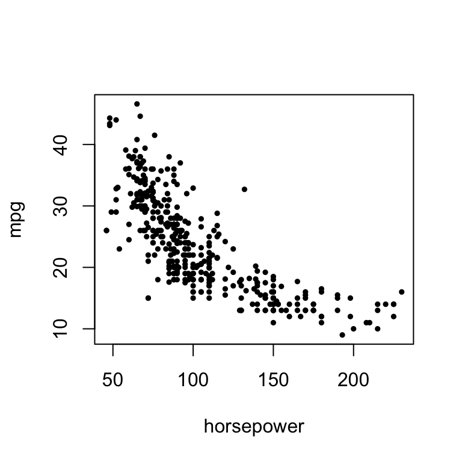

```r
plot(mpg ~ horsepower, data = Auto, cex = 0.5, pch = 19)
```

- 변수 `horsepower`로 `mpg`(연비)를 예측하고자 함
- 다음의 다항회귀(polynomial regression) 후보 모형들을 고려
  - mpg ~ horsepower
  - mpg ~ horsepower + horsepower${}^2$

  $\qquad\cdots$
  - mpg ~ horsepower + horsepower${}^2$ + $\cdots$ + horsepower${}^p$
- 모형 선택 과정
  1. 훈련자료(196개) 및 평가자료(196개)로 `Auto` 데이터를 랜덤하게 분할
  2. 훈련자료를 사용하여 $p$개 모형을 적합
  3. 위에서 적합된 $p$개의 모형을 평가자료에 적용하여 모형을 평가: 회귀문제이므로 Mean Squared Error(MSE)를 이용
  4. MSE가 가장 낮은 모형을 선택

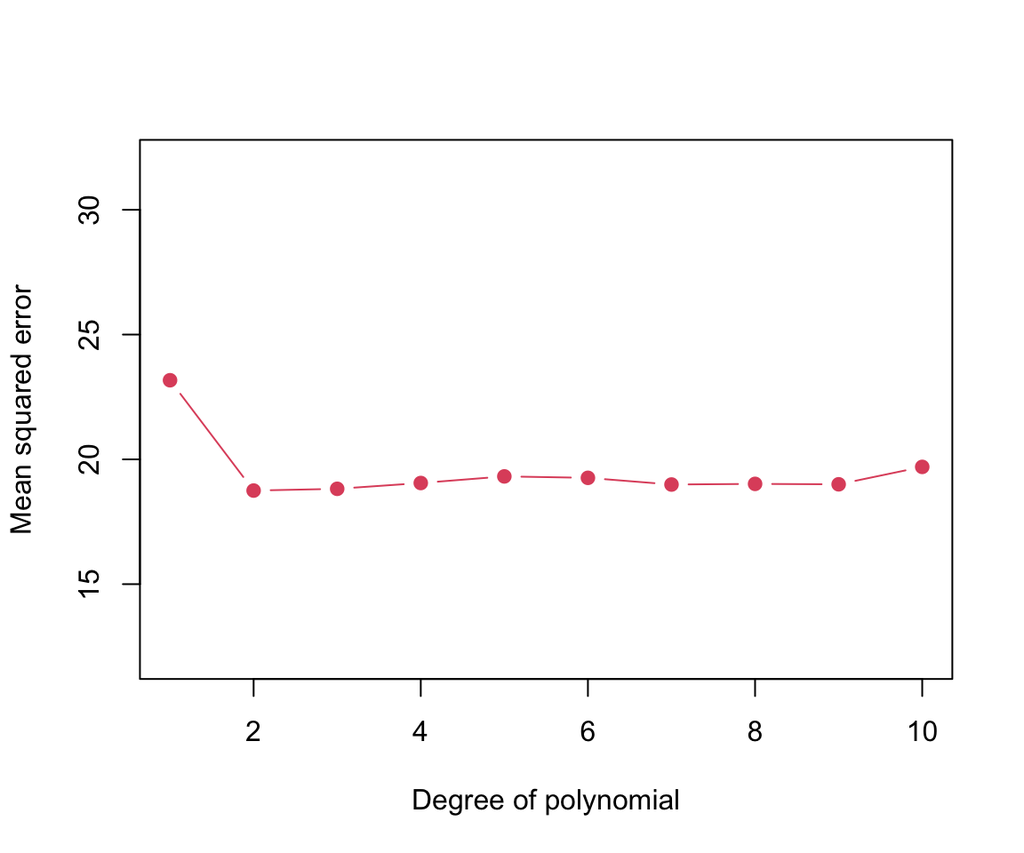

```r
set.seed(0)

N <- nrow(Auto)
tr <- sample(1:N, round(N/2), replace = FALSE)
Auto.tr <- Auto[tr,]
Auto.val <- Auto[-tr,]

mse <- rep(NA, 10)
for ( p in 1:10 ) {
  fit <- lm(mpg ~ poly(horsepower, p), data = Auto.tr)
  mse[p] <- mean((predict(fit, Auto.val) - Auto.val$mpg)^2)
}
plot(1:10, mse, type = "b", pch = 19, col = 2, ylim = c(12, 32),
     xlab = "Degree of polynomial", ylab = "Mean squared error")
```

- 위 작업을 12회 반복
  - 결과마다 validation MSE 값들이 상당히 다른 패턴을 보임. 더 안정적인 방법이 필요.

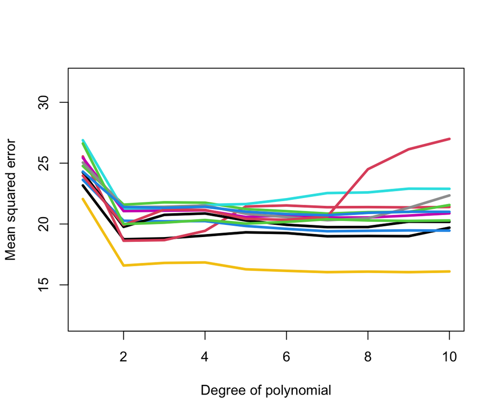

```r
M <- 12
plot(1:10, mse, type = "l", lwd = 3, ylim = c(12, 32),
     xlab = "Degree of polynomial", ylab = "Mean squared error")
for ( j in 2:M ) {
  tr <- sample(1:N, round(N/2), replace = FALSE)
  Auto.tr <- Auto[tr,]
  Auto.val <- Auto[-tr,]
  mse <- rep(NA, 10)
  for ( p in 1:10 ) {
    fit <- lm(mpg ~ poly(horsepower, p), data = Auto.tr)
    mse[p] <- mean((predict(fit, Auto.val) - Auto.val$mpg)^2)
  }
  lines(1:10, mse, col = j, lwd = 3)
}
```

- Validation set approach의 장단점
  - 장점: 이해하기 쉽고 간단히 구현됨
  - 단점
    - 분할에 따라 validation MSE의 변동이 심하기 때문에 test MSE의 추정치로 사용하기에 부적절함
    - 훈련자료의 일부분만 훈련에 이용, precision에 손해를 보게 됨

## Leave-One-Out Cross Validation (LOOCV)

- LOOCV는 Validation set approach의 단점을 보완한 방법임

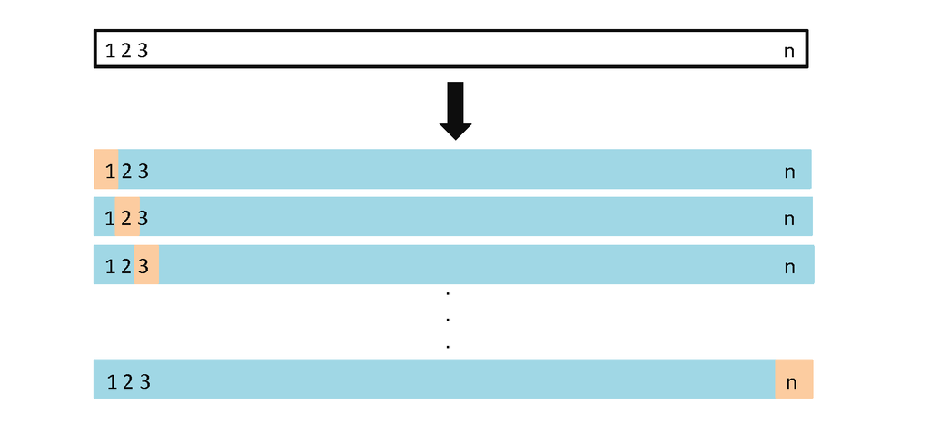

- Validation MSE 계산을 위한 LOOCV 알고리즘
  1. $i = 1$로 둠
  2. 훈련자료를 다음과 같이 분할
     - 훈련자료: $\{1, 2, 3, ..., n\}\setminus \{i\}$
     - 평가자료: $\{i\}$
  3. 2에서 정한 훈련자료를 사용해 모형을 학습시키고, 학습된 모형을 2에서 정한 평가자료에 적용해 제곱오차 ${\sf SE}_i$를 계산
  4. $i = n$이면 단계 5로 이동. 아니면 $i = i + 1$로 업데이트하고, 단계 2로 이동.
  5. Cross-validation으로 구한 MSE
     $${\sf CV}_{(n)} = \frac{1}{n}\sum_{i=1}^n {\sf SE}_i$$
- 장단점
  - 장점
    - 매 반복 시마다 $n-1$개의 훈련자료를 이용. 즉 자료의 대부분을 활용하여 학습.
    - Validation set approach는 분할 과정에서 임의성(randomness)이 개입되어 반복마다 MSE값이 달라지는 반면, LOOCV는 하나의 MSE 값을 도출
  - 단점
    - 계산집약적(computationally intensive)

## K-fold Cross Validation

- 계산집약적인 LOOCV의 단점을 보완하기 위해 K-fold cross validation(K-fold CV)을 사용

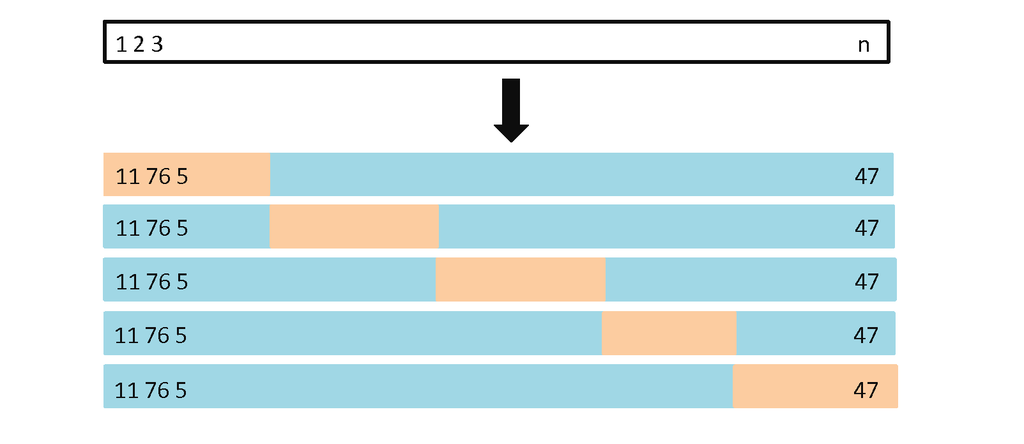

- K-fold CV 알고리즘
  1. 훈련자료를 랜덤하게 shuffle
  2. 훈련자료를 $K$개로 랜덤하게 분할. $k=1$로 둠.
  3. $k$번째 fold를 평가자료로, 나머지 $K-1$개의 fold를 훈련자료로 둠
  4. 3에서 정한 훈련자료를 사용해 모형을 학습시키고, 학습된 모형을 3에서 정한 평가자료에 적용해 평균제곱오차 ${\sf MSE}_k$를 계산
  5. $k = K$이면 단계 6으로 이동. 아니면 $k = k + 1$로 업데이트하고, 단계 3으로 이동.
  6. $K$개의 MSE의 평균으로 cross-validated MSE를 계산.
     $${\sf CV}_{(K)} = \frac{1}{K}\sum_{k=1}^K {\sf MSE}_k$$

#### 예제 데이터 분석: `Auto` 데이터

- LOOCV

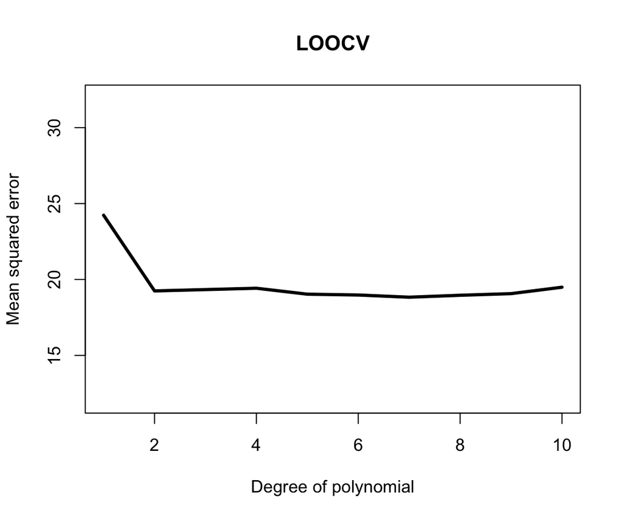

```r
mse <- rep(0, 10)
for ( p in 1:10 ) {
  for ( i in 1:N ) {
    tr <- Auto[-i,]
    val <- Auto[i,]
    fit <- lm(mpg ~ poly(horsepower, p), data = tr)
    mse[p] <- mse[p] + (predict(fit, val) - val$mpg)^2
  }
}
mse <- mse/N
plot(1:10, mse, type = "l", lwd = 3, ylim = c(12, 32), main = "LOOCV",
     xlab = "Degree of polynomial", ylab = "Mean squared error")
```

- 5-fold CV

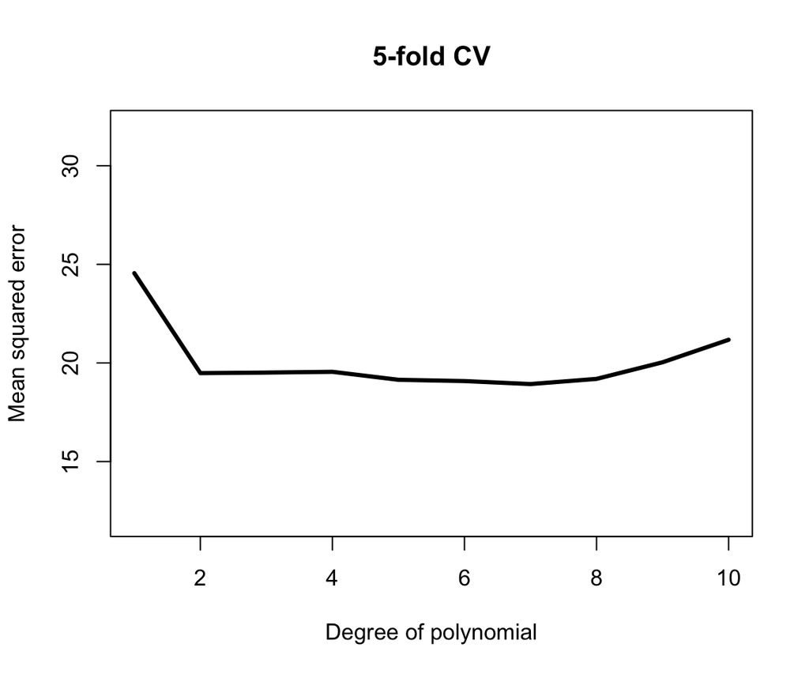

```r
set.seed(0)
K <- 5
M <- round(N/K)
V <- matrix(0, K, 2)
for ( k in 1:K ) {
  V[k,] <- c(M*(k - 1) + 1, min(M*k, N))
}

ind <- sample(1:N)

mse <- matrix(NA, K, 10)
for ( k in 1:K ) {
  val <- ind[V[k, 1]:V[k, 2]]
  tr <- ind[-(V[k, 1]:V[k, 2])]
  for ( p in 1:10 ) {
    fit <- lm(mpg ~ poly(horsepower, p), data = Auto, subset = tr)
    mse[k, p] <- mean((predict(fit, Auto[val,]) - Auto$mpg[val])^2)
  }
}
CV <- colMeans(mse)

plot(1:10, CV, type = "l", lwd = 3, ylim = c(12, 32),
     main = paste(k, "-fold CV", sep = ""),
     xlab = "Degree of polynomial", ylab = "Mean squared error")
```

- K-fold CV는 반복 시행마다 MSE 추정값 패턴이 달라지게 되지만 비교적 안정적인 모형 선택 결과를 제공함:

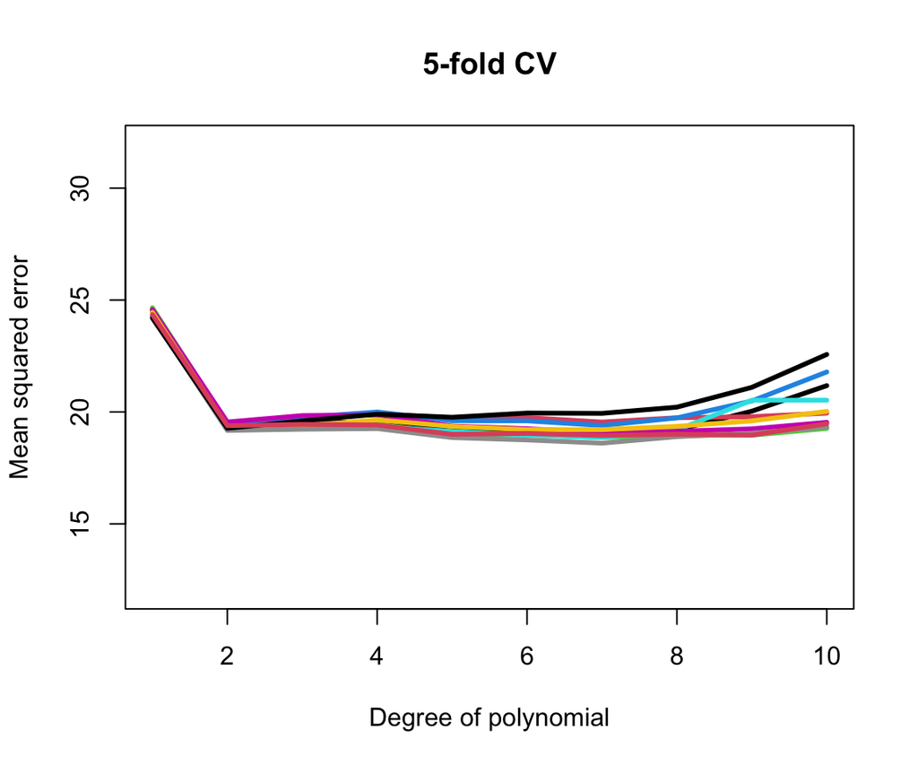

```r
plot(1:10, CV, type = "l", lwd = 3, ylim = c(12, 32),
     main = paste(k, "-fold CV", sep = ""),
     xlab = "Degree of polynomial", ylab = "Mean squared error")
for ( j in 2:10 ) {
  ind <- sample(1:N)
  mse <- matrix(NA, K, 10)
  for ( k in 1:K ) {
    val <- ind[V[k, 1]:V[k, 2]]
    tr <- ind[-(V[k, 1]:V[k, 2])]
    for ( p in 1:10 ) {
      fit <- lm(mpg ~ poly(horsepower, p), data = Auto, subset = tr)
      mse[k, p] <- mean((predict(fit, Auto[val,]) - Auto$mpg[val])^2)
    }
  }
  CV <- colMeans(mse)
  lines(1:10, CV, lwd = 3, col = j)
}
```

- 분류 문제에 K-fold cross Validation를 적용
  1. $K$ folds로 자료를 랜덤하게 분할
  2. 폴드별로 한 개씩 교대로 평가자료로 지정하고 나머지 폴드를 훈련자료로 사용해 학습된 모형을 평가자료에 적용해 error rate를 계산
  3. CV error rate은 $K$개 폴드에서 구한 오분류율의 평균으로 계산